# Demo: A Quick Look at Data Retrieved from Climate Manager

## Demo: A Quick Look at Data Retrieved from Climate Manager

#### PYR Air Quality Science Unit

#### 201-401 Burrard St.

#### Vancouver, BC, V6C 3S5

#### Last updated: 2014-05-22

### Contents

- Introduction
- Definitions
- Some Plots
- Notes and Future Work

### Introduction

In this demo, we look to see if there is a relationship between high precipitation events and high wind speed events. A procedure for identifying high precipitation events is outlined, and the associated wind speeds in periods before, during and after high precipitation events are checked to see if there exists empirical evidence that suggests a correlation exists between the two weather variables.

**Daily Total Precipitation (mm)** data and **Hourly Wind Speed (km/h)** data from 24 stations in the PYR region (see table below) were gathered using an `R` script that queries Environment Canada's internal website, [Climate Manager](http://daytona.pyr.ec.gc.ca/%7Ewebcm/cm.pl), for data. The data was collected for the interval period between the years 1979 to 2012. It was noted that for there were missing data points for varying time intervals at different stations within this time period.

The station name, three letter station code, station ID in Climate Manager, approximate latitude and longitude, and region are displayed in the following table. The station name and station ID were retrieved from Climate Manager. The other variables were retrieved from Google Earth using Environment Canada's spatial data packaged in `kmz` files (located in the network share: `\\PYRVANFP07\PWCusers\Common\PUBLIC_Program\PUBLIC_Program_ABase\Community Forecast\`).

| Name | Station | StationId | Longitude | Latitude | Region |
| --- | --- | --- | --- | --- | --- |
| VICTORIA INT'L A | YYJ | 1018620 | -123.42 | 48.63 | Greater Victoria |
| ABBOTSFORD A | YXX | 1100030 | -122.37 | 49.03 | Fraser Valley |
| NANAIMO A | YCD | 1025370 | -123.87 | 49.05 | East Vancouver Island |
| TOFINO A | YAZ | 1038205 | -125.77 | 49.07 | West Vancouver Island |
| VANCOUVER INT'L A | YVR | 1108447 | -123.17 | 49.20 | Greater Vancouver |
| HOPE SLIDE | WKV | 1113581 | -121.23 | 49.28 | Similkameen |
| PENTICTON A | YYF | 1126150 | -119.60 | 49.45 | Okanagan Valley |
| CRANBROOK A | YXC | 1152102 | -115.78 | 49.62 | East Kootenay |
| COMOX A | YQQ | 1021830 | -124.88 | 49.70 | East Vancouver Island |
| SQUAMISH | WSK | 10476F0 | -123.17 | 49.78 | Howe Sound |
| WHISTLER | WAE | 1048898 | -122.95 | 50.13 | Whistler |
| PORT HARDY A | YZT | 1026270 | -127.37 | 50.68 | North Vancouver Island |
| KAMLOOPS A | YKA | 1163780 | -120.43 | 50.70 | South Thompson |
| REVELSTOKE A | YRV | 1176749 | -118.18 | 50.97 | West Columbia |
| WILLIAMS LAKE A | YWL | 1098940 | -122.05 | 52.18 | Cariboo |
| QUESNEL A | YQZ | 1096630 | -122.50 | 53.02 | Cariboo |
| SANDSPIT A | YZP | 1057050 | -131.80 | 53.25 | Queen Charlottes |
| PRINCE GEORGE A | YXS | 1096450 | -122.68 | 53.88 | Prince George |
| PRINCE RUPERT A | YPR | 1066481 | -130.45 | 54.28 | North Coast - coastal sections |
| TERRACE A | YXT | 1068130 | -128.57 | 54.47 | North Coast - inland sections |
| SMITHERS A | YYD | 1077500 | -127.18 | 54.82 | Bulkley Valley and The Lakes |
| FORT ST JOHN A | YXJ | 1183000 | -120.73 | 56.23 | B.C. Peace River |
| FORT NELSON A | YYE | 1192940 | -122.60 | 58.83 | Fort Nelson |
| WHITEHORSE A | YXY | 2101300 | -135.07 | 60.72 | Whitehorse |

The locations of these stations are shown on a simple map. On the left, the station locations in a map of BC and the Yukon are displayed, and on the right, we zoom in on the Lower Mainland area to better display the station locations.

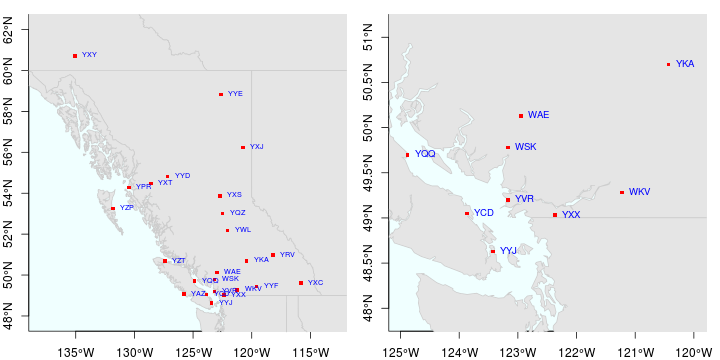

```r
# Lets plot BC!
# Split the plotting window and set the plot margins
par(mfrow=c(1,2), mar=c(2,2,1,1))

# Plot the big picture
plot(can, xlim=c(-138,-113), ylim=c(48,62), axes=TRUE,
     bg="azure", col="grey90", border="grey80")
plot(usa, col="grey90", add=TRUE,border="grey80")
plot(sdata, add=TRUE, col="red", pch=".", cex=5)
text(slot(sdata, "coords")[, "lon"], slot(sdata, "coords")[, "lat"],
     labels=sdata$station, pos=4, cex=0.6, col="blue")

# Zoom in on greater vancouver area
plot(can, xlim=c(-125,-120), ylim=c(48,51), axes=TRUE,
     bg="azure", col="grey90", border="grey80")
plot(usa, col="grey90", add=TRUE, border="grey80")
plot(sdata, add=TRUE, col="red", pch=".", cex=5)
text(slot(sdata, "coords")[, "lon"], slot(sdata, "coords")[, "lat"],
     labels=sdata$station, pos=4, cex=0.8, col="blue")
```

For each station, a data set was downloaded for the two variables of interest. The **daily precipitation data** contains a *date* field (`year`, `month`, `day` variables) and the observation field (24 hour cumulative precipitation (mm), or `precip`). The **hourly wind data** is similar daily data, but with an additional date field for the `hour` of the observed `wind` speed (km/h).

In Climate Manager, the daily cumulative precipitation is labelled “Total Precipitation” in the daily data (variable number 12), and the hourly wind speed is labelled as “Wind Speed” in the hourly data (variable number 76).

### Definitions

According to Environment Canada, Total Precipitation is defined as [“The sum of the total rainfall and the water equivalent of the total snowfall in millimetres (mm), observed at the location during a specified time interval.”](http://climate.weather.gc.ca/glossary_e.html#totalPrec).

The hourly Wind Speed is defined as [“The speed of motion of air in kilometres per hour (km/h) usually observed at 10 metres above the ground.”](http://climate.weather.gc.ca/glossary_e.html#windSpd). In addition, the average wind speed is calculated during the two-minute period ending at the time of observation.

#### Defining High Precipitation Events

We defined high precipitation events according to Environment Canada's Public Alerting Criteria. The following were copied from an internal Environment Canada website:

**Summer**

| Location | Threshold Criteria |
| --- | --- |
| Inland Vancouver Island, West Vancouver Island, North Vancouver Island, Central Coast coastal sections, North Coast coastal sections | When 100 mm or more of rain is expected within 24 hours. |
| Okanagan Valley, Nicola, South Thompson, Boundary | When 25 mm or more of rain is expected within 12 hours, or when 75 mm or more of rain is expected within 48 hours. |
| Remainder of British Columbia & Yukon | When 50 mm or more of rain is expected within 24 hours or when 75 mm or more of rain is expected within 48 hours. |

**Winter**

| Location | Threshold Criteria |
| --- | --- |
| Inland Vancouver Island, West Vancouver Island, North Vancouver Island, Central Coast coastal sections, North Coast coastal sections | When 100 mm or more of rain is expected within 24 hours. |
| Remainder of British Columbia and Haines Skagway Roads | When 50 mm or more of rain is expected within 24 hours, or when 75 mm or more of rain is expected within 48 hours. |
| Yukon | When 25 mm or more of rain is expected within 24 hours. |

**During Thaw Only**

| Location | Threshold Criteria |
| --- | --- |
| Okanagan, Similkameen, Nicola, Fraser Canyon, South Thompson, Shuswap, West Kootenay, Boundary, and Arrow Lakes/Slocan Lakes: **mid-April to early June** | When 25 mm or more of rain is expected to within 24 hours. |
| Columbias, Kootenay Lake, East Kootenay, Elk Valley: **mid-April to late June** | When 25 mm or more of rain is expected to within 24 hours. |
| Central Interior, Williston, McGregor, Bulkley Valley, Fort Nelson, Muncho Lake Park-Stone Mountain Park, B.C. Peace River: **mid-April to mid-June** | When 25 mm or more of rain is expected to within 24 hours. |
| Dease Lake, Cassiar Mountains, Atlin: **mid-April to mid-July** | When 25 mm or more of rain is expected to within 24 hours. |

#### Wind Speed Data

Once high precipitation events were identified, the relevant Wind Speed data points in a 72 hour window centered around the high precipitation event were isolated. For example, if we observed an event of interest on 2012-06-15, we would retrieve the hourly wind data from 2012-06-14 00:00:00 to 2012-06-16 24:00:00 (i.e. 2012-06-17 00:00:00).

Once we had the wind speed data associated with the high precipitation events, we calculated a rolling 6 hour maximum of the hourly average wind speed. Missing values were ignored for this calculation.

#### A Technical Note

Once the data were downloaded from the Climate Manager as `csv` files, the data were entered into an [SQLite](http://www.sqlite.org/) database using the [RSQLite](http://cran.r-project.org/web/packages/RSQLite/index.html) `R` package. This allowed for efficient querying of the data.

### Some Plots

#### Warning Levels of Precipitation, according to EC Public Alerting Criteria

Following Environment Canada's Public Alerting Criteria, we tabulate the total number of events that warranted a public alert. This is shown in the following table, and depicted in the bar plot below.

| YKA | YZT | YXS | YYF | YQZ | YPR | YRV | YYD | YXC | YZP | YXJ | YYE | YVR | YYJ | WAE | YCD | YQQ | YAZ | WKV | YXT | YXX | WSK | Total |
| --- | --- | --- | --- | --- | --- | --- | --- | --- | --- | --- | --- | --- | --- | --- | --- | --- | --- | --- | --- | --- | --- | --- |
| 1 | 1 | 2 | 2 | 3 | 4 | 4 | 8 | 11 | 11 | 13 | 14 | 17 | 20 | 26 | 28 | 33 | 39 | 49 | 75 | 85 | 329 | 775 |

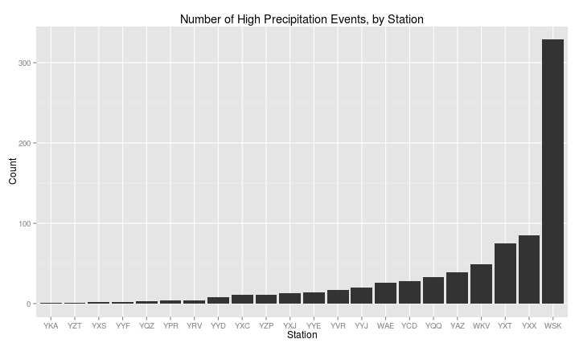

```r
# Plot!
ggplot(data=numPrecipEvents, aes(x=label, y=n)) +
  geom_bar(stat='identity') +
  xlab("Station") + ylab("Count") +
  ggtitle("Number of High Precipitation Events, by Station")
```

It seems that the WSK station (SQUAMISH) exhibits the highest number of high precipitation events - more than 3 times the number of the next highest station. This is, in part, due to the number of of observations included in the data due to the 48 hour warning levels of precipitation. Of the 216 observations that were included due to the 48 hour warning levels, 122 of those came from the WSK station. The number of 48 hour warning level precipitation events are shown in the next table.

| YYD | YXJ | YYE | YVR | YCD | YQQ | YYJ | WAE | WKV | YXX | YXT | WSK | Total |
| --- | --- | --- | --- | --- | --- | --- | --- | --- | --- | --- | --- | --- |
| 1 | 1 | 1 | 2 | 4 | 5 | 6 | 6 | 13 | 26 | 29 | 122 | 216 |

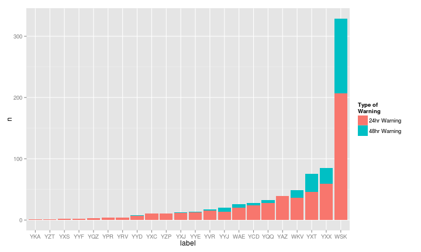

#### When do High Precipitation Events Occur?

We also take a look at *when* high precipitation events were observed. The data is summarized by year, then by month.

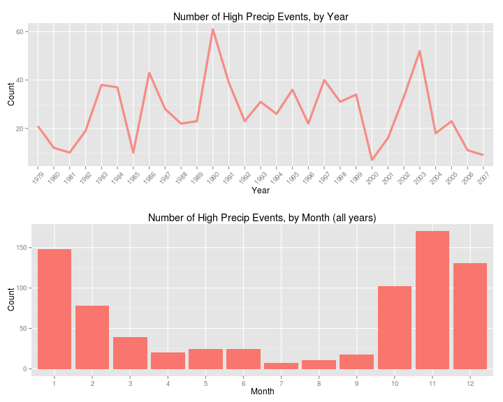

```r
# Plot yearly trend
ggprecip1 <- ggplot(precip.results.all) +
  geom_path(aes(x=year, group=type, colour=type),
            stat="bin", size=1.5, alpha=0.8) +
  xlab("Year") + ylab("Count") +
  ggtitle("Number of High Precip Events, by Year") +
  theme(axis.text.x=element_text(angle=45, vjust=0.5)) +
  scale_colour_discrete(guide=FALSE, "Type of Event",
                        labels=c("EC Public Alert",">= 50mm Precip"))

# Aggregate by month for all years
ggprecip2 <- ggplot(precip.results.all) +
  geom_bar(aes(x=month, group=type, fill=type), stat="bin",
           position="dodge") +
  xlab("Month") + ylab("Count") +
  ggtitle("Number of High Precip Events, by Month (all years)") +
  scale_fill_discrete(guide=FALSE, "Type of Event",
                        labels=c("EC Public Alert",">= 50mm Precip"))

# Show two plots together
grid.arrange(ggprecip1, ggprecip2)
```

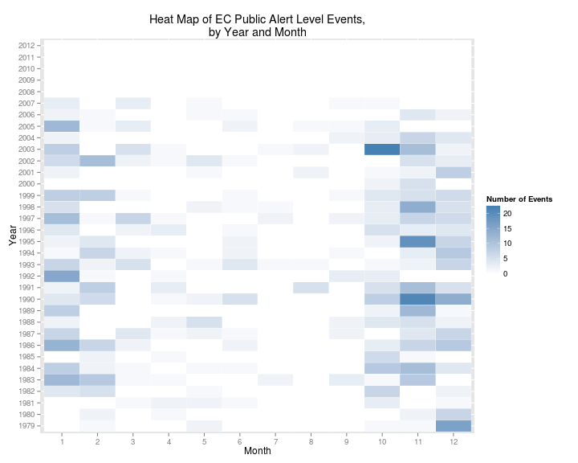

```r
# Heatmap
ggplot(data=precip.heat1) +
  geom_tile(aes(y=as.factor(year), x=as.factor(month),
                fill=n), colour="white") +
  scale_fill_gradient("Number of Events",
                      low="white", high="steelblue") +
  ylab("Year") + xlab("Month") +
  ggtitle("Heat Map of EC Public Alert Level Events,\nby Year and Month")
```

#### Wind Speeds During/Before/After a High Precipitation Event

When considering the wind speed data, we are working with hourly data. The precipitation data, on the other hand, was in the form of daily data. Since we are looking at winds during/before/after a precipitation event, we must consider 72 wind data points for every high precipitation event.

##### EC Public Alert Thresholds

First, we consider the wind speed when we use the EC Public Alert levels to determine high precipitation events. We present a daily aggregate representation of the wind speed in a combined violin and box plot. A black solid line indicates the station's overall mean wind speed, and the dashed black line indicates the station's overall mean calculated when winds were > 0 km/h.

A table is provided as a reference to how many high precipitation events were observed.

| YKA | YZT | YXS | YYF | YQZ | YPR | YRV | YYD | YXC | YZP | YXJ | YYE | YVR | YYJ | WAE | YCD | YQQ | YAZ | WKV | YXT | YXX | WSK | Total |
| --- | --- | --- | --- | --- | --- | --- | --- | --- | --- | --- | --- | --- | --- | --- | --- | --- | --- | --- | --- | --- | --- | --- |
| 1 | 1 | 2 | 2 | 3 | 4 | 4 | 8 | 11 | 11 | 13 | 14 | 17 | 20 | 26 | 28 | 33 | 39 | 49 | 75 | 85 | 329 | 775 |

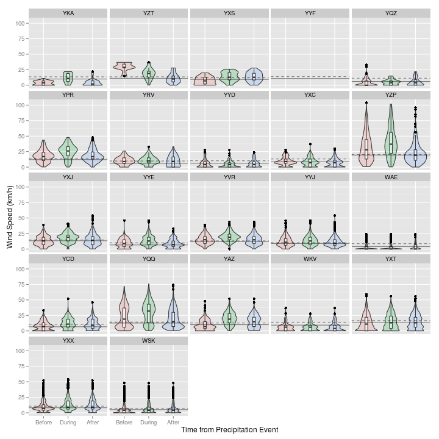

```r
# Violin + boxplot
ggplot(wind.6hMax) +
  geom_violin(aes(x=lagDay, y=avgWind_kmh, group=lagDay,
                  fill=as.factor(lagDay)), alpha=0.2) +
  geom_boxplot(aes(x=lagDay, y=avgWind_kmh, group=lagDay),
               width=0.15, alpha=0.5) +
  geom_hline(data=subset(wind.dat.avg, label %in% unique(wind.6hMax$label)),
             aes(yintercept=overallMeanWind, by=label),
             alpha=0.5) +
  geom_hline(data=subset(wind.dat.avg.no0, label %in% unique(wind.6hMax$label)),
             aes(yintercept=overallMeanWind, by=label),
             alpha=0.5, linetype="dashed") +
  theme(legend.position="none") +
  facet_wrap(~label) +
  ylab("Wind Speed (km/h)") + xlab("Time from Precipitation Event")
```

Turning our attention to the violin/box plots, we can take a look at the distribution of wind speeds on the day before, the day of, and the day after a high precipitation event. The two horizontal lines specify the station mean (solid black) and the zero-removed mean (dashed black), and serves as a point of comparison. The wind speed observations seem vary by station location. The 11 observations from YZP (SANDSPIT A) exhibit larger variance than the other stations, reaching wind speeds of up to 100 km/h during some high precipitation events. It is not clear from these plots whether higher wind speeds are observed during times of heavy precipitation.

#### Missing Values

##### Precipitation Data

We begin by investigating the number of missing data points in the precipitation data, by station and by year. These are plotted below:

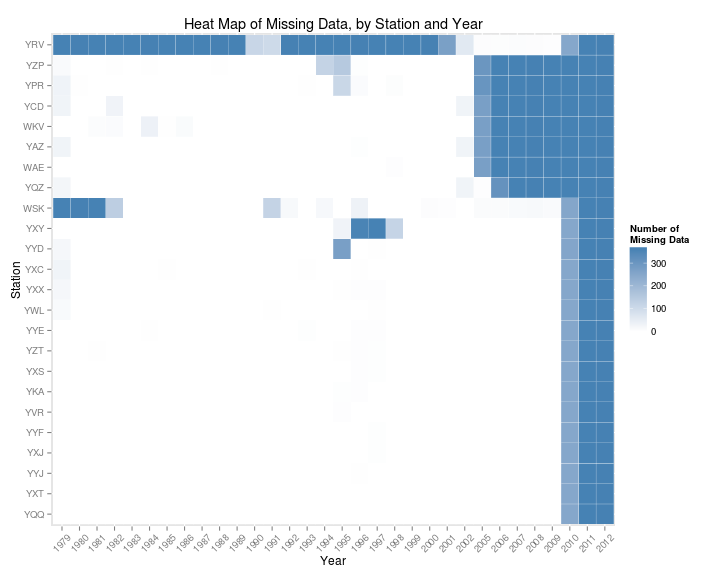

```r
# Heatmap
ggplot(data=precip.heat) +
  geom_tile(aes(x=as.factor(year), y=label,
                fill=numberNA), colour="white") +
  scale_fill_gradient("Number of\nMissing Data",
                      low="white", high="steelblue")+
  theme(axis.text.x=element_text(angle=45, vjust=0.5)) +
  ylab("Station") + xlab("Year") +
  ggtitle("Heat Map of Missing Data, by Station and Year")
```

##### Wind Data

Next we look at the number of missing data points in the entire wind data set.

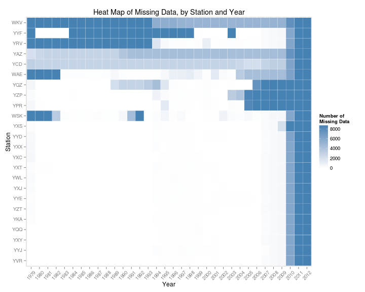

```r
# Heatmap
ggplot(data=wind.heat) +
  geom_tile(aes(x=as.factor(year), y=label,
                fill=numberNA), colour="white") +
  scale_fill_gradient("Number of\nMissing Data",
                      low="white", high="steelblue")+
  theme(axis.text.x=element_text(angle=45, vjust=0.5)) +
  ylab("Station") + xlab("Year") +
  ggtitle("Heat Map of Missing Data, by Station and Year")
```

### Notes

The above figures do not constitute a full statistical analysis, but serve only as a first look into the data. No formal connection has been made to show a whether a correlation between high precipitation events and high wind speed exists.